# Analyse de stabilité

```python
# Fusion avec le dataframe de référence B0 :
df_T2 = df_T2.merge(df_T0['customer_unique_id'], on='customer_unique_id')
print(df_T2.shape)
```

```
(41073, 5)
```

B3 à la date T3 - 3 mois de plus

```python
start = dt.datetime.strptime('2017-01-01 00:00:00', '%Y-%m-%d %H:%M:%S')
end = dt.datetime.strptime('2018-04-01 00:00:00', '%Y-%m-%d %H:%M:%S')

rec_3 = rec(data, start, end)
freq_3 = freq(data, start, end)
montant_3 = montant(data, start, end)
avis_mean_3 = avis_mean(data, start, end)
df_T3 = make_df(rec_3, freq_3, montant_3, avis_mean_3)
```

```python
# Fusion avec le dataframe de référence B0 :
df_T3 = df_T3.merge(df_T0['customer_unique_id'], on='customer_unique_id')
print(df_T3.shape)
```

```
(41073, 5)
```

B4 à la date T4 - 4 mois de plus

```python
start = dt.datetime.strptime('2017-01-01 00:00:00', '%Y-%m-%d %H:%M:%S')
end = dt.datetime.strptime('2018-05-01 00:00:00', '%Y-%m-%d %H:%M:%S')

rec_4 = rec(data, start, end)
freq_4 = freq(data, start, end)
montant_4 = montant(data, start, end)
avis_mean_4 = avis_mean(data, start, end)
df_T4 = make_df(rec_4, freq_4, montant_4, avis_mean_4)
```

```python
# Fusion avec le dataframe de référence B0 :
df_T4 = df_T4.merge(df_T0['customer_unique_id'], on='customer_unique_id')
print(df_T4.shape)
```

```
(41073, 5)
```

B5 à la date T5 - 5 mois de plus

```python
start = dt.datetime.strptime('2017-01-01 00:00:00', '%Y-%m-%d %H:%M:%S')
end = dt.datetime.strptime('2018-06-01 00:00:00', '%Y-%m-%d %H:%M:%S')

rec_5 = rec(data, start, end)
freq_5 = freq(data, start, end)
montant_5 = montant(data, start, end)
avis_mean_5 = avis_mean(data, start, end)
df_T5 = make_df(rec_5, freq_5, montant_5, avis_mean_5)
```

```python
# Fusion avec le dataframe de référence B0 :
df_T5 = df_T5.merge(df_T0['customer_unique_id'], on='customer_unique_id')
print(df_T5.shape)
```

```
(41073, 5)
```

B6 à la date T6 - 6 mois de plus

```python
start = dt.datetime.strptime('2017-01-01 00:00:00', '%Y-%m-%d %H:%M:%S')
end = dt.datetime.strptime('2018-07-01 00:00:00', '%Y-%m-%d %H:%M:%S')

rec_6 = rec(data, start, end)
freq_6 = freq(data, start, end)
montant_6 = montant(data, start, end)
avis_mean_6 = avis_mean(data, start, end)
df_T6 = make_df(rec_6, freq_6, montant_6, avis_mean_6)
```

```python
# Fusion avec le dataframe de référence B0 :
df_T6 = df_T6.merge(df_T0['customer_unique_id'], on='customer_unique_id')
print(df_T6.shape)
```

```
(41073, 5)
```

B7 à la date T7 - 7 mois de plus

```python
start = dt.datetime.strptime('2017-01-01 00:00:00', '%Y-%m-%d %H:%M:%S')
end = dt.datetime.strptime('2018-08-01 00:00:00', '%Y-%m-%d %H:%M:%S')

rec_7 = rec(data, start, end)
freq_7 = freq(data, start, end)
montant_7 = montant(data, start, end)
avis_mean_7 = avis_mean(data, start, end)
df_T7 = make_df(rec_7, freq_7, montant_7, avis_mean_7)
```

```python
# Fusion avec le dataframe de référence B0 :
df_T7 = df_T7.merge(df_T0['customer_unique_id'], on='customer_unique_id')
print(df_T7.shape)
```

```
(41073, 5)
```

B8 à la date T8 - 8 mois de plus

```python
start = dt.datetime.strptime('2017-01-01 00:00:00', '%Y-%m-%d %H:%M:%S')
end = dt.datetime.strptime('2018-08-29 00:00:00', '%Y-%m-%d %H:%M:%S')

rec_8 = rec(data, start, end)
freq_8 = freq(data, start, end)
montant_8 = montant(data, start, end)
avis_mean_8 = avis_mean(data, start, end)
df_T8 = make_df(rec_8, freq_8, montant_8, avis_mean_8)
```

```python
# Fusion avec le dataframe de référence B0 :
df_T8 = df_T8.merge(df_T0['customer_unique_id'], on='customer_unique_id')
print(df_T8.shape)
```

```
(41073, 5)
```

**Clustering**

Pour déterminer le moment où les clients changent de cluster, nous allons **itérer le K-Means sur toute la période avec des deltas de 1 mois** et calculer le score ARI, en prenant garde à bien comparer les mêmes clients (ceux des 12 mois initiaux).

```python
from sklearn.preprocessing import PowerTransformer

def clustering (df):
    df = df[['Récence', 'Fréquence', 'Montant', 'Avis moy']].copy()

    # Transformation des données pour k-means
    # PowerTransformer est le meilleur transformer en termes de prise en compte des outliers
    transformer = PowerTransformer(method='yeo-johnson')
    df_normalized = transformer.fit_transform(df)

    # k-means sur données transformées
    kmeans = KMeans(n_clusters=5, random_state=1)
    kmeans.fit(df_normalized)

    # récupération des labels
    return kmeans.labels_
```

A présent, nous allons récupérer les labels dans une liste :

```python
liste_labels_cls = []

cls_labels_t0 = clustering(df_T0)

cls_labels_t1 = clustering(df_T1)
liste_labels_cls.append(cls_labels_t1)

cls_labels_t2 = clustering(df_T2)
liste_labels_cls.append(cls_labels_t2)

cls_labels_t3 = clustering(df_T3)
liste_labels_cls.append(cls_labels_t3)

cls_labels_t4 = clustering(df_T4)
liste_labels_cls.append(cls_labels_t4)

cls_labels_t5 = clustering(df_T5)
liste_labels_cls.append(cls_labels_t5)

cls_labels_t6 = clustering(df_T6)
liste_labels_cls.append(cls_labels_t6)

cls_labels_t7 = clustering(df_T7)
liste_labels_cls.append(cls_labels_t7)

cls_labels_t8 = clustering(df_T8)
liste_labels_cls.append(cls_labels_t8)
```

```python
liste_labels_cls
```

```
[array([4, 3, 2, ..., 3, 0, 0], dtype=int32),
 array([2, 1, 0, ..., 1, 4, 4], dtype=int32),
 array([2, 0, 4, ..., 0, 1, 1], dtype=int32),
 array([4, 0, 3, ..., 0, 1, 1], dtype=int32),
 array([1, 0, 3, ..., 0, 2, 2], dtype=int32),
 array([1, 4, 0, ..., 4, 2, 2], dtype=int32),
 array([1, 3, 0, ..., 1, 2, 2], dtype=int32),
 array([3, 4, 1, ..., 3, 0, 0], dtype=int32)]
```

**Calcul du score ARI - Adjusted Rand Index**

L'indice de Rand peut être gonflé artificiellement en prédisant beaucoup de clusters : les paires de points appartenant à des clusters différents seront nombreuses, et il y aura de grandes chances que deux points étiquetés différemment soient dans deux clusters différents.

**L'indice de Rand ajusté** (ARI, pour Adjusted Rand Index) corrige cet effet en normalisant l'indice de Rand (RI).

Cet index ajusté est proche de 0 pour un clustering aléatoire et égal à 1 uniquement quand le clustering correspond exactement à la partition initiale.

A présent nous allons calculer les scores ARI et ensuite afficher leur évolution.

```python
from sklearn.metrics import silhouette_score, adjusted_rand_score

ARI_SCORES = []

for i in liste_labels_cls:
    ARI_SCORES.append(adjusted_rand_score(cls_labels_t0, i))
```

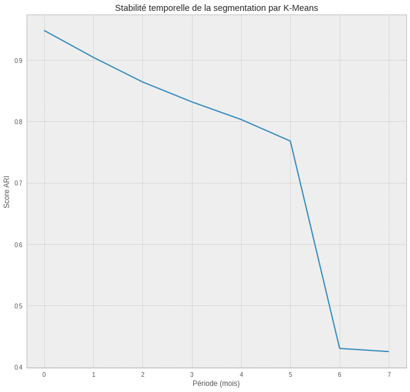

```python
plt.figure(figsize=(10,10))
plt.style.use("bmh")
plt.plot(ARI_SCORES)
plt.xlabel("Période (mois)")
plt.ylabel("Score ARI")
plt.title("Stabilité temporelle de la segmentation par K-Means")
plt.show()
```

### Conclusion

Sur le graphique nous observons des scores ARI obtenus sur les itérations par période de 1 mois. Nous remarquons **une forte inflexion** après 5 mois sur les clients initiaux.

Il faudra donc **prévoir la maintenance du programme de segmentation tous les 5 mois** dans un premier temps puis re-tester cette stabilité temporelle au fil du temps afin de l'affiner. Il sera donc nécessaire de redéfinir les segments clients à chaque maintenance.

**Sources**

https://www.kaggle.com/code/michaelfumery/e-commerce-customers-segmentation/notebook https://scikit-learn.org/stable/modules/generated/sklearn.metrics.adjusted_rand_score.html

https://openclassrooms.com/fr/courses/4379436-explorez-vos-donnees-avec-des-algorithmes-non-supervises/4379556-definissez-les-criteres-que-doit-satisfaire-votre-clustering